# Explaining suicide in Italian counties

02 dicembre 2014

## What and Why

## A quick background:

- Among young adults (15-29), suicide accounts for 8.5% of all deaths: *second leading cause of death* (after traffic accidents).
- Among adults (30-49) suicide accounts for 4.1% of all deaths: *fifth leading cause of death* (latest "Prevent Suicide" report by WHO).
- "The debate about the impact of climate change on human health has, very recently, included consideration of mental health" (Berry, Bowen & Kjellstrom, 2009).
- The *mental health vs climate* relationship still needs to be studied into details (**research gap**).

## Research question:

*How do climate factors affect suicide rate in the Italian context?*

- Is suicide rate lower whereby the average temperature is higher?
- Is suicide rate higher whereby the average temperature range is higher?
- Is suicide rate higher whereby precipitations happen more frequently?

## Methodology

## Case selection:

Previous study: regional data, 20 observations, unsignificant model.

Now, Italy is still our focus: *county-level data* provide 110 observations!

[figure not shown]

## Our Model:

\[ StdSuicideRate = \alpha + \beta_{1}GdpPerCapita + \beta_{2}Unemployment \] \[ + \beta_{3}Population + \beta_{4}GiniIndex + \beta_{5}AverageTemperature \] \[ + \beta_{6}AverageTemperatureRange + \beta_{7}AveragePrecipitations + e \]

## A Second, improved, model:

\[ StdSuicideRate = \alpha + \beta_{1}GdpPerCapita + \beta_{2}Population \] \[ + \beta_{3}AverageTemperature + \beta_{4}AveragePrecipitations + e \]

## Results

## Models Comparison:

| First Model | Second Model |
| --- | --- |
| GDP per capita*** | GDP per capita*** |
| Unemployment Rate | *dropped* |
| Population*** | Population*** |
| Gini index | *dropped* |
| Avg Temperature | Avg Temperature |
| Avg Temp. Range | *dropped* |
| Avg Precipitations*** | Avg Precipitations*** |

## Findings:

- **Average temperatures** and **Temperature range** have no impact on suicide rate across Italy
- **GDP per capita** has a positive impact on suicides (in Italy).
- **Population size** has a negative impact on suicides.
- **Annual precipitations** has a negative impact on suicides.

## Predicted Probabilities:

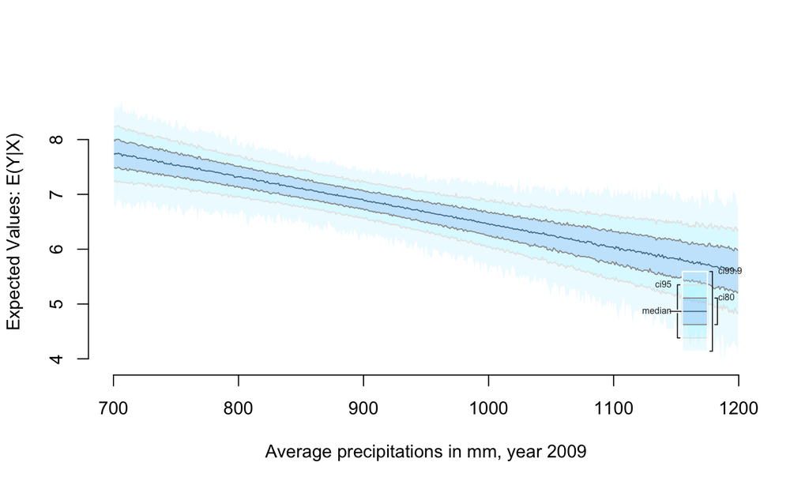

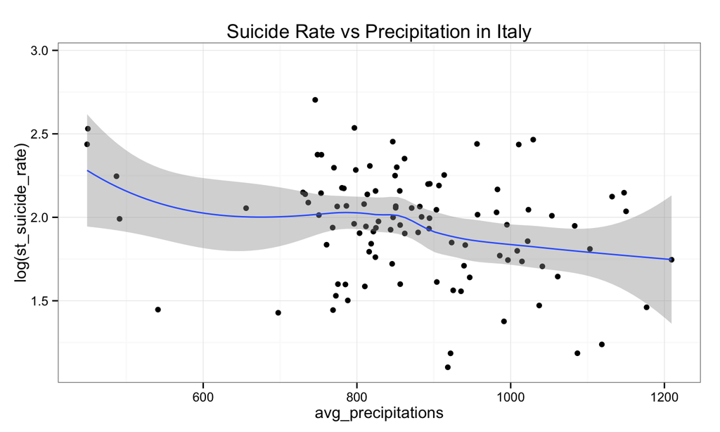

## Conclusion:

- *Climate characteristics do affect suicide rates in Italy.*
- Correlation not as strong as (we) would have expected.
- Rain actually has a negative impact on suicidial behaviour (contrary to what is commonly believed).
- A one percentage increase in average precipitations decreases suicide rate by 0,461 percent.

## Limitations and Further Research:

- Data: only 2009. Panel data analysis?
- Further applications to test whether precipitations and sucide rates are negatively correlated also in other developed countries.
- Test other climatic factors (e.g. solar radiation)?
- Test it with monthly data looking for seasonal patterns for suicide.

## Thank you for your attention!